# Meeting 13-04

## Model Selection - Split

- Proposed train, test, validation split given by strafified region and complexity.
- Each split is given by a seed, which allows error and stanadrd deviation out of the seed-runs.

#### Per-Site Stratified Random Splitting

Per-Site: each geographical island is an independent unit, to prevent spatial bias.

Stratified: maintaining the ratio of "High/Medium/Low" complexity in every set.

Random Splitting given by: stochastic selection to ensure generalizability.

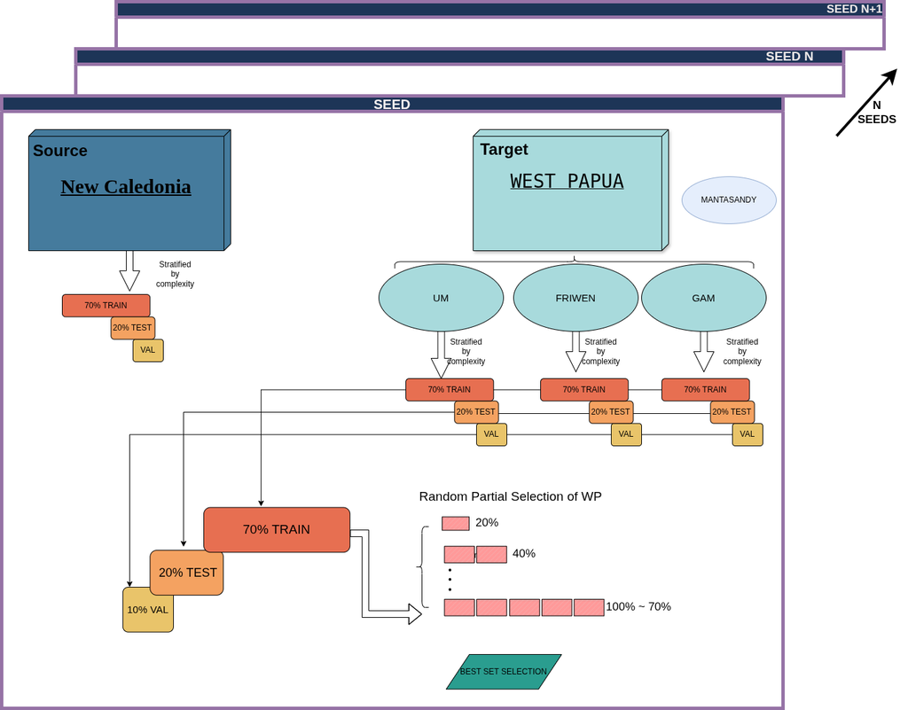

- The train set can be subset on different partitions from Target dataset. Which means that the model trained on Source can be fine-tunned through x% of the training set. The maximum partition represents the full division of the train set (70%). An arbitrary choice.
- By subsetting the train target, it is possible to analyse the results regarding transferability and model learning, as well to dig with Active Learning topic, in order to analyse if does it exists a best set of images that can be labelled which leverages models performance and therefore decreases the labelling process.
- The presented split, also allows the analysis of intrinsic dimensions regarding different subsets and some levels of stratification (geographically and object complexity).
- The following split also allows an easily integration for further experiment with Teacher-Student network and knowledge distillation

## Model Choice

- RT-DETR

Model Specificities:

- Checkpoint save: 'mAp50'
- Confidence = 0.3
- Max Epochs = 100
- Early Stopping = 20
- Learning Rate = 5e-5
- Optimizer AdamW.
- **Augmentation.**

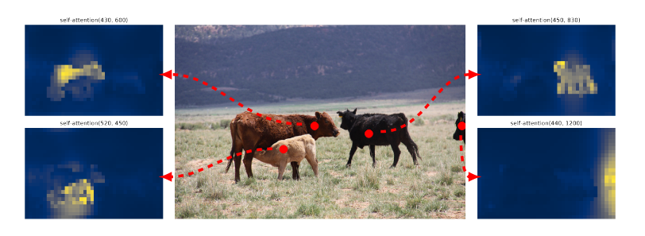

## Optimized Sliced Inference and Training

Since the drone images are quite big (2500x3500) and different size orders, instead of interpolating and resizing the image for a given standard. Taking in consideration that the object is very small regarding the full scene, slicing the images to avoid the lost of essencial pixels regarding the object was taken as essential for properly assessment.

The images are chop down in a set of tile with fix size (640x640) to match same dimensions used on RT-DETR paper. These tiles receives the a suffix tile_0_640 and can be easily 'sew' back.

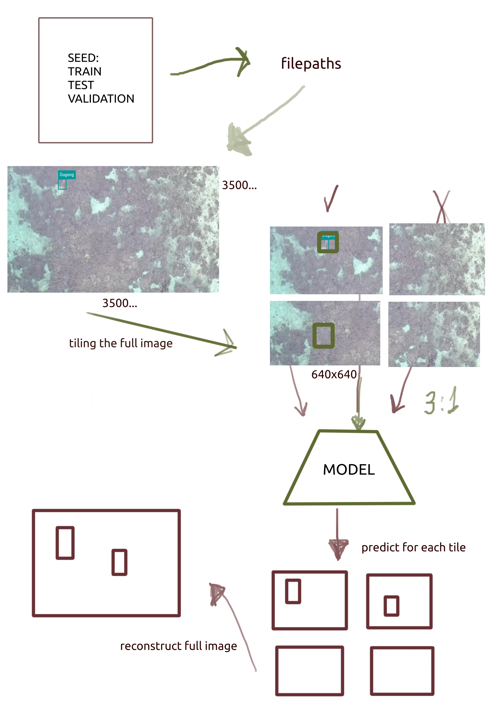

# Training Schema

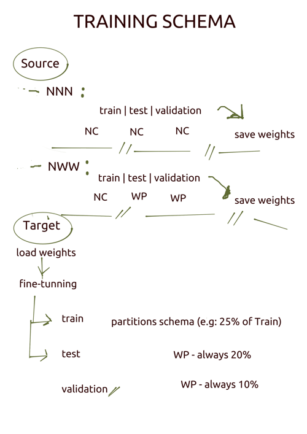

| Schema | Training Set | Validation Set (for saving weights) | Purpose |
| --- | --- | --- | --- |
| Schema A (In-Domain) | Source | Source | Standard supervised learning. Aims for the best performance on the Source distribution. |
| Schema B (Cross-Domain) | Source | Target | Domain Generalization. Aims to find the exact moment during training when the model is best at "translating" Source knowledge to the Target. |

For the first stage: Transferability between source and target domains is optimized through a two-stage training strategy. In the first stage, the model is trained on the source distribution. We evaluate performance using two distinct validation schemas: In-Domain Validation (Source) and Cross-Domain validation (Target).

These selected weights serve as a robust initialization for the second stage: Target Fine-Tuning.

By doing it the model is converging on converging on the training set but the best model selection is given by the target distribution.

## Experiments

Total number of models current running:

First Stage Schema:

- NNN
- NWW

Second Stage Schema:

- Random Selection
  - Partition 10
  - Partition 25
  - Partition 50 ~ 35% of the train dataset
  - Partition 75 ~ 52.5% of the train dataset
  - Partition 100 ~ 70% of the train dataset
- Best Set Selection (Uniqueness, embedding, knn)
  - Partition 10
  - Partition 25
  - Partition 50

### Proposes for further experiments

- Teacher - Student framework. (Knowledge Distillation)
- Augmentation techniques to approximate distribution from target to source (using Optimal Transport)

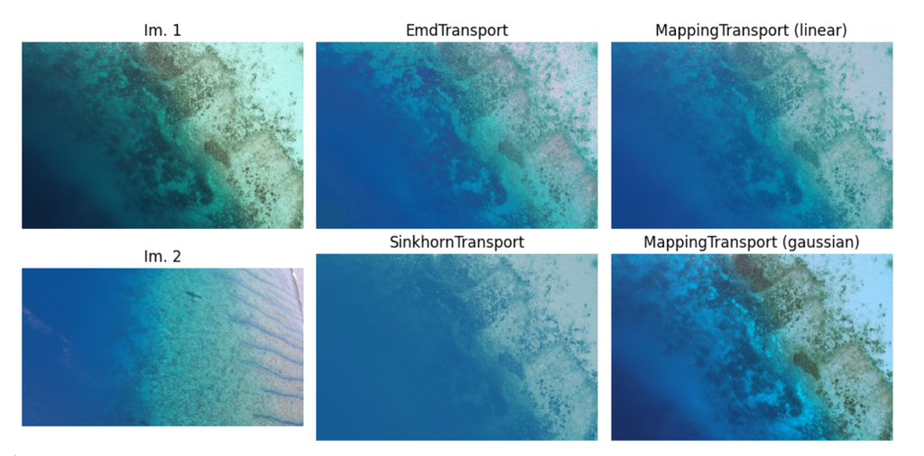

#### teacher student framework

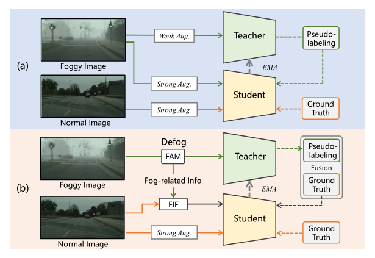

[1] H. Qin, X. Lu, L. Wang, and Y. Wang, ‘Foggy-Aware Teacher: An Unsupervised Domain Adaptive Learning Framework for Object Detection in Foggy Scenes’, IEEE Robot. Autom. Lett., vol. 10, no. 7, pp. 7508–7515, Jul. 2025, doi: 10.1109/LRA.2025.3575306.

Thank you

```python
## Load dataset and views from mongodb
dataset = fo.load_dataset("dugong")

## load the views
nc_view = dataset.load_saved_view("New_Caledonia")
wp_view = dataset.load_saved_view("West_Papua")
```

```python
view_GAM = wp_view.match(
    F("subregion")=="GAM"
)
view_FRIWEN = wp_view.match(
    F("subregion")=="FRIWEN"
)
view_MANTASANDY = wp_view.match(
    F("subregion")=="MANTASANDY"
)
view_UM = wp_view.match(
    F("subregion")=="UM"
)

print("Number of images per geographical location")
print(f"WP- GAM: {len(view_GAM)}")
print(f"WP - FRIWEN: {len(view_FRIWEN)}")
print(f"WP - MANTASANDY: {len(view_MANTASANDY)}")
print(f"WP -UM: {len(view_UM)}")
print(f"NC: {len(nc_view)}")
print(f"WP (total): {len(wp_view)}")
```

```
Number of images per geographical location
```

```
WP- GAM: 512
WP - FRIWEN: 779
WP - MANTASANDY: 3
WP -UM: 745
NC: 716
WP (total): 2039
```

```python
dict_wp = {
    'um':view_UM,
    'gam':view_GAM,
    'mantasandy':view_MANTASANDY,
    'friwen':view_FRIWEN
}

for name, dd in dict_wp.items():
    ## count the number of objects
    print(f"Running:{name}")

    number_of_objects = dd.count("ground_truth.detections")
    print(f"Number of objects:{number_of_objects}")

    # Filter detections in the 'audit' field
    medium_complexity_bg = dd.filter_labels(
        "audit",
        F("background_complexity") == "medium"
    )

    high_complexity_bg = dd.filter_labels(
        "audit",
        F("background_complexity") == "high"
    )

    low_complexity_bg = dd.filter_labels(
        "audit",
        F("background_complexity") == "low"
    )

    # Check how many detections matched
    print(f"Number of images as:")
    high = dd.match(F("background_complexity") == "high")
    medium = dd.match(F("background_complexity") == "medium")
    low = dd.match(F("background_complexity") == "low")
    print(f"high: {high.count()}")
    print(f"medium: {medium.count()}")
    print(f"low: {low.count()}")
    print('- - '*2)
    print(f"OBJECTS")
    print('high complexity',high_complexity_bg.count("audit.detections"))
    print("medium complexity",medium_complexity_bg.count("audit.detections"))
    print("low complexity",low_complexity_bg.count("audit.detections"))
    print('-'*30)
```

```
Running:um
Number of objects:1308
Number of images as:
high: 4
medium: 741
low: 0
- - - -
OBJECTS
high complexity 6
medium complexity 1302
low complexity 0
------------------------------
Running:gam
Number of objects:997
Number of images as:
high: 299
medium: 61
low: 152
- - - -
OBJECTS
high complexity 571
medium complexity 122
low complexity 304
------------------------------
Running:mantasandy
Number of objects:3
Number of images as:
high: 2
medium: 1
low: 0
- - - -
OBJECTS
high complexity 2
medium complexity 1
low complexity 0
------------------------------
Running:friwen
Number of objects:1307
Number of images as:
high: 4
medium: 775
low: 0
- - - -
OBJECTS
high complexity 0
medium complexity 1302
low complexity 0
------------------------------
```

## Strategy for Splitting between train and test

### Per-Site Stratified Random Splitting

Per-Site: each geographical island is an independent unit, to prevent spatial bias.

Stratified: maintaining the ratio of "High/Medium/Low" complexity in every set.

Random Splitting: stochastic selection to ensure generalizability.

```python
from fiftyone import ViewField as F
import fiftyone.utils.random as four

# create a combined key: e.g., "WP_UM_medium" or "WP_GAM_high"
# ensures the split respects both the location and the difficulty
dataset.set_values(
    "stratify_key",
    [f"{r}_{m}_{c}" for r, m, c in zip(
        dataset.values("region"),
        dataset.values("subregion"),
        dataset.values("background_complexity")
    )]
)

print("Unique strata created:", dataset.count_values("stratify_key"))
```

```
Unique strata created: {'WP_MANTASANDY_medium': 1, 'WP_MANTASANDY_high': 2, 'WP_GAM_high': 299, 'WP_GAM_medium': 61, 'NC_NC_low': 108, 'WP_GAM_low': 152, 'NC_NC_medium': 270, 'NC_NC_high': 338, 'WP_FRIWEN_medium': 775, 'WP_UM_high': 4, 'WP_FRIWEN_high': 4, 'WP_UM_medium': 741}
```

```python
dataset.count_values("subregion")
```

```
{'MANTASANDY': 3, 'FRIWEN': 779, 'GAM': 512, 'NC': 716, 'UM': 745}
```

```python
from sklearn.model_selection import train_test_split
import pandas as pd

## percentage of each train, val, test
train_size = 0.7
test_size = 0.2
val_size = 0.1
random_state = 42

# target islands (skipping MANTASANDY)
islands_to_split = ['UM', 'GAM', 'FRIWEN']

# clear old tags to start fresh
dataset.untag_samples(["train", "test", "val"])

for island in islands_to_split:
    # Get a view of just this island
    island_view = dataset.match(F("subregion") == island)

    ids = island_view.values("id")

    # Our strata is the complexity (high/medium/low)
    strata = island_view.values("background_complexity")

    # Split off the TEST set (20%) ---
    # Stratify ensures the 'high complexity' ratio stays the same
    train_val_ids, test_ids = train_test_split(
        ids,
        test_size= test_size,
        stratify=strata,
        shuffle=True,
        random_state=random_state
    )

    # Get strata for the remaining 80% to split again
    train_val_strata = [s for i, s in zip(ids, strata) if i in train_val_ids]

    # Split remaining 80% into Train (70% total) and Val (10% total) ---
    # 0.125 * 0.8 = 0.1 (which is 10% of the original total)
    train_ids, val_ids = train_test_split(
        train_val_ids,
        test_size= (val_size/(1-test_size)),
        stratify=train_val_strata,
        random_state=random_state
    )

    # 3. Apply the tags in FiftyOne
    dataset.select(train_ids).tag_samples("train")
    dataset.select(val_ids).tag_samples("val")
    dataset.select(test_ids).tag_samples("test")

    print(f"Island {island}: Train={len(train_ids)}, Test={len(test_ids)}, Val={len(val_ids)}")

# 4. Add New Caledonia to 'train' only
nc_view = dataset.match(F("region") == "NC")
nc_view.tag_samples("train")

print('dataset split:')
print(f"train {wp_view.count_values('tags')['train'] + nc_view.count_values('tags')['train']}")
print('test',wp_view.count_values('tags')['test'])
print('val',wp_view.count_values('tags')['val'])
```

[output not shown]

### Repeated Random Sub-sampling Validation

```python
dataset.distinct("tags")
```

```python
# clear old tags to start fresh
dataset.untag_samples(["train", "test", "val"])


# collect all tags in dataset
all_tags = dataset.distinct("tags")

# keep only those starting with "train_"
tags_to_remove = [t for t in all_tags if t.startswith("train_")]

# delete them
dataset.untag_samples(tags_to_remove)
```

```python
from sklearn.model_selection import train_test_split
import pandas as pd


def tag_train_test_split_seeded(train_size:float,test_size:float,val_size:float,
                                runs:int,
                                dataset):
    """
    Creates the split for train, test and validation using a stratified pick given by the complexity.
    Args:
        runs: Number of loop to pass and create the tag inside the dataset

        Returns:
        Return the seed_number and the dataset get tagged.
    """
    # target islands (skipping MANTASANDY)
    islands_to_split = ['UM', 'GAM', 'FRIWEN']
    seeds_list = []

    ## tags adding train_seed_number for west papua
    for run in range(0,runs+1):
        seed_number  = random.randint(1,50)
        print(f"Seed number selected:{seed_number}")
        seeds_list.append(seed_number)
        for island in islands_to_split:
            # Get a view of just this island
            island_view = dataset.match(F("subregion") == island)

            ids = island_view.values("id")

            # Our strata is the complexity (high/medium/low)
            strata = island_view.values("background_complexity")

            # Split off the TEST set (20%) ---
            # Stratify ensures the 'high complexity' ratio stays the same
            train_val_ids, test_ids = train_test_split(
                ids,
                test_size= test_size,
                stratify=strata,
                shuffle=True,
                random_state=seed_number
            )

            # Get strata for the remaining 80% to split again
            train_val_strata = [s for i, s in zip(ids, strata) if i in train_val_ids]

            # Split remaining 80% into Train (70% total) and Val (10% total) ---
            # 0.125 * 0.8 = 0.1 (which is 10% of the original total)
            train_ids, val_ids = train_test_split(
                train_val_ids,
                test_size= (val_size/(1-test_size)),
                stratify=train_val_strata,
                random_state=seed_number
            )

            # 3. Apply the tags in FiftyOne
            dataset.select(train_ids).tag_samples(f"train_{str(seed_number)}")
            dataset.select(val_ids).tag_samples(f"val_{str(seed_number)}")
            dataset.select(test_ids).tag_samples(f"test_{str(seed_number)}")

            print(f"Island {island}: Train={len(train_ids)}, Test={len(test_ids)}, Val={len(val_ids)}")

    return seeds_list


def get_files_by_stem(filepath_stem, folder):
    dict_out = {}
    foolder_meta = os.path.join(folder, 'metadata')
    list_meta = list(glob.glob(os.path.join(foolder_meta, f'{filepath_stem}__*.json')))
    foolder_meta = os.path.join(folder, 'images')
    list_images = list(glob.glob(os.path.join(foolder_meta, f'{filepath_stem}__*.jpg')))
    foolder_meta = os.path.join(folder, 'labels')
    list_labels = list(glob.glob(os.path.join(foolder_meta, f'{filepath_stem}__*.txt')))
    dict_out['metadata'] = list_meta
    dict_out['label'] = list_labels
    dict_out['images'] = list_images
    return dict_out


## use the function to run
folder =  '/share/home/e2406743/dataset/exported_img/seed_42'
## percentage of each train, val, test
train_size = 0.7
test_size = 0.2
val_size = 0.1
runs = 1

seed_number_list = tag_train_test_split_seeded(train_size, test_size, val_size,
                                          runs=runs,
                                          dataset= dataset
                                          )

## tag TRAIN for all new caledonia samples.
nc_view = dataset.match(F("region") == "NC")
nc_view.tag_samples("train")
```

```
Seed number selected:23
Island UM: Train=521, Test=149, Val=75
Island GAM: Train=357, Test=103, Val=52
Island FRIWEN: Train=545, Test=156, Val=78
Seed number selected:11
Island UM: Train=521, Test=149, Val=75
Island GAM: Train=357, Test=103, Val=52
Island FRIWEN: Train=545, Test=156, Val=78
```

```python
def return_list_filepath_train_test_val(seed_number, dataset, nc_view):
    train_seed_filepath = dataset.match_tags(f"train_{seed_number}").values("filepath")
    test_seed_filepath = dataset.match_tags(f"test_{seed_number}").values("filepath")
    val_seed_filepath = dataset.match_tags(f"val_{seed_number}").values("filepath")
    train_nc_filepath = nc_view.match_tags("train").values("filepath")
    return train_seed_filepath, test_seed_filepath, val_seed_filepath, train_nc_filepath


def build_filepath_df(train_seed_filepath, test_seed_filepath, val_seed_filepath, train_nc_filepath):

    df = pd.DataFrame({
        "train_seed": pd.Series(train_seed_filepath),
        "test_seed": pd.Series(test_seed_filepath),
        "val_seed": pd.Series(val_seed_filepath),
        "train_nc": pd.Series(train_nc_filepath),
    })

    return df



## IMPLEMENT LOOP HERE
## RUN ALL GIVEN SEEDS AND CREATES A CSV WITH THE PATHS REGARDING THE FULL IMAGE
for ss in seed_number_list:
    print(f"Running seed:{ss}")
    train_seed_filepath, test_seed_filepath, val_seed_filepath, train_nc_filepath = return_list_filepath_train_test_val(
        ss, dataset=dataset, nc_view=nc_view
    )

    df_seed = build_filepath_df(
        train_seed_filepath,
        test_seed_filepath,
        val_seed_filepath,
        train_nc_filepath
    )

    ## save it keeping
    output_filename = f"df_train_test_split_filepath_{str(ss)}"
    print(f"saving file:{output_filename}")
    output_folder = "/share/home/e2406743/dataset/df_filepaths"
    os.makedirs(output_folder, exist_ok=True)
    print(f"saving at:{os.path.join(output_folder,output_filename)}")
    df_seed.to_csv(os.path.join(output_folder, output_filename))
    print('done!')
```

```
Running seed:23
saving file:df_train_test_split_filepath_23
saving at:/share/home/e2406743/dataset/df_filepaths/df_train_test_split_filepath_23
done!
Running seed:11
saving file:df_train_test_split_filepath_11
saving at:/share/home/e2406743/dataset/df_filepaths/df_train_test_split_filepath_11
done!
```

```python
## LOAD THE DF WITH PATHS AND PREPARE TO BE SAMPLED
```

[output not shown]

```python
vv = wp_view.values('filepath')
ss = nc_view.values('filepath')
dd = vv +ss

folder =  '/share/home/e2406743/dataset/exported_img/seed_42'
dict_map_filepath = {}
for path in dd:
    stem = Path(path).stem
    dict_map_filepath[stem] = get_files_by_stem(stem, folder)

## flat dict
filepath_all_images   = [f for d in dict_map_filepath.values() for f in d.get('images', [])]
filepath_all_labels   = [f for d in dict_map_filepath.values() for f in d.get('label', [])]
filepath_all_metadata = [f for d in dict_map_filepath.values() for f in d.get('metadata', [])]

## -------------
print(f'images:{len(filepath_all_images)}')
print(f"labels:{len(filepath_all_labels)}")
print(f"metadata:{len(filepath_all_metadata)}")
```

```
images:10008
labels:10008
metadata:10008
```

```python
# list with NC train
# list with WP train 10%
# list with WP train 20% ... 70%
# list with selected optimization
```